# Explore Polysaccharide Binding

Many of the TanOak genes coming up with high dN/dS in the polysaccharide binding category are LRK10L2 homologs. The goal here is to align the TanOak paralogs with other related homologs, build a tree, and see where changes are happening.

Previously I blasted against the NR database, and that was a bit of a mess for building a tree. Will try again, but with BLAST against selected organisms.

```r
library(tidyverse)
library(Biostrings)
library(UpSetR)
library(gplots)
```

## Sequence retrieval

Start with blastp of `../output/polysaccharide_peps.fa`

Used phyotozome blastp tool against:

- Athaliana_TAIR10_167.proteome;
- Qrubra_v2_1_687.proteome;
- Cdentata_v1_1_673.proteome;
- Gmax_Wm82_a4_v1_508.proteome;
- Ptrichocarpa_v4_1_533.proteome

Job is at https://phytozome-next.jgi.doe.gov/blast-results/589527

Results table, retrieved peptides and cDNAs are in `output/blastp/polysaccharide_Seq_downloads/phytozome_blastp

## Sequence overlap

Have common sequences been retrieved for the different queries?

```r
hittable <- read_tsv("../output/polysaccharide_seq_downloads/phytozome_blastp/phytozome_polysach_blastp_071522.tsv",
                     name_repair = make.names) %>%
  select(-1) %>%
  mutate(fasta.name = str_c({str_replace(Species, " ", "_") %>% str_replace("\\.", "") },
                            str_extract(Protein, "[A-Za-z]*\\.?[A-Za-z0-9]*"),
                            sep="|") )
head(hittable)
```

| Views | Protein | Species | E.value | X..identity | Align.len | Strands | Query.ID | Query.from | Query.to | Target.from | Target.to | Bitscore | X..identical | Positives | Gaps | Query.len | Target.len | fasta.name |
| --- | --- | --- | --- | --- | --- | --- | --- | --- | --- | --- | --- | --- | --- | --- | --- | --- | --- | --- |
| phytozome-next.jgi.doe.gov/report/protein/Cdentata_v1_1/Caden.12G048400.1.p | Caden.12G048400.1.p | C.dentata v1.1 | 2.05e-146 | 86 | 262 | +/+ | augustus_masked-585_pilon-processed-gene-3.11-mRNA-1 | 1 | 260 | 1 | 260 | 427.557 | 226 | 234 | 4 | 261 | 674 | Cdentata_v1.1\|Caden.12G048400 |
| phytozome-next.jgi.doe.gov/report/protein/Qrubra_v2_1/Qurub.09G043700.1 | Qurub.09G043700.1 | Q.rubra v2.1 | 4.64e-115 | 73 | 256 | +/+ | augustus_masked-585_pilon-processed-gene-3.11-mRNA-1 | 1 | 254 | 1 | 253 | 345.510 | 186 | 210 | 5 | 261 | 621 | Qrubra_v2.1\|Qurub.09G043700 |
| phytozome-next.jgi.doe.gov/report/protein/Cdentata_v1_1/Caden.12G048100.1.p | Caden.12G048100.1.p | C.dentata v1.1 | 2.85e-102 | 71 | 238 | +/+ | augustus_masked-585_pilon-processed-gene-3.11-mRNA-1 | 28 | 261 | 2 | 229 | 311.227 | 170 | 193 | 14 | 261 | 572 | Cdentata_v1.1\|Caden.12G048100 |
| phytozome-next.jgi.doe.gov/report/protein/Cdentata_v1_1/Caden.12G048600.1.p | Caden.12G048600.1.p | C.dentata v1.1 | 1.93e-101 | 67 | 260 | +/+ | augustus_masked-585_pilon-processed-gene-3.11-mRNA-1 | 1 | 260 | 1 | 245 | 311.612 | 174 | 202 | 15 | 261 | 662 | Cdentata_v1.1\|Caden.12G048600 |
| phytozome-next.jgi.doe.gov/report/protein/Qrubra_v2_1/Qurub.04G259800.1 | Qurub.04G259800.1 | Q.rubra v2.1 | 2.30e-95 | 63 | 263 | +/+ | augustus_masked-585_pilon-processed-gene-3.11-mRNA-1 | 1 | 261 | 1 | 253 | 283.108 | 167 | 192 | 12 | 261 | 254 | Qrubra_v2.1\|Qurub.04G259800 |
| phytozome-next.jgi.doe.gov/report/protein/Cdentata_v1_1/Caden.12G049300.1.p | Caden.12G049300.1.p | C.dentata v1.1 | 3.74e-91 | 59 | 265 | +/+ | augustus_masked-585_pilon-processed-gene-3.11-mRNA-1 | 1 | 256 | 1 | 262 | 283.878 | 156 | 186 | 12 | 261 | 618 | Cdentata_v1.1\|Caden.12G049300 |

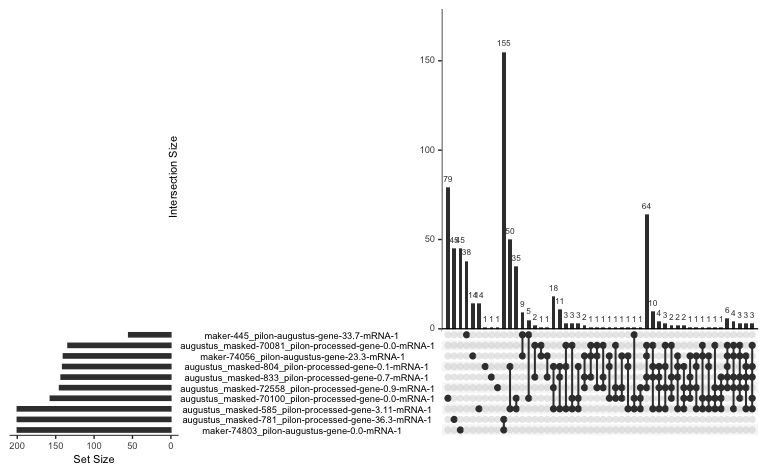

```r
hit.counts <- hittable %>% select(Protein, Query.ID) %>%
  unique() %>%
  table() %>%
  as.data.frame.matrix()

upset(hit.counts, nsets = 10, nintersects = 50)
```

70100 (Wall-associated receptor kinase galacturonan-binding; Wall-associated receptor kinase C-terminal; LRK10L3),  
445 (Wall-associated receptor kinase galacturonan-binding; Wall-associated receptor kinase C-terminal); NA Are unique:

585 (NA; LRK10L2) and  
804 (Wall-associated receptor kinase galacturonan-binding; ATL21) can be grouped together

781 (EGF-like domain profile.; Wall-associated receptor kinase galacturonan-binding; Serine/Threonine protein kinases active-site signature.; Protein kinase domain; Wall-associated kinase; EGF_CA; Protein kinase domain profile. ;WAK5 ) AND  
74803 (Calcium-binding EGF-like domain signature.; EGF-like domain profile.; Wall-associated receptor kinase galacturonan-binding; Calcium-binding EGF domain; EGF_CA; EGF-like domain signature 2.; Aspartic acid and asparagine hydroxylation site.; WAK2 ) can be grouped together

70081 (NA; ATL21),  
72558 (Wall-associated receptor kinase galacturonan-binding; ATL21), and  
833 (Wall-associated receptor kinase galacturonan-binding; ATL21), AND 74056 (NA; ATL96) can be grouped together

## Qrob homologs

Do blast to get all Qrob homologs

```r
cd ../input/blast
blastp -query ../../output/polysaccharide_peps.fa -db Qrob_PM1N_CDS_aa_20161004.fa -outfmt 7 > ../../output/polysaccharide_Qrob_blast.tsv
```

```r
header <- str_split("query acc.ver, subject acc.ver, % identity, alignment length, mismatches, gap opens, q. start, q. end, s. start, s. end, evalue, bit score", pattern = ", ") %>%
  unlist() %>%
  make.names() %>%
  str_replace(fixed(".."), ".") %>%
  str_replace("X", "pct")

Qrob_hittable <- read_tsv("../output/polysaccharide_Qrob_blast.tsv", comment = "#", col_names = header)
Qrob_hittable
```

| query.acc.ver | subject.acc.ver | pct.identity | alignment.length | mismatches | gap.opens | q.start | q.end | s.start | s.end | evalue | bit.score |
| --- | --- | --- | --- | --- | --- | --- | --- | --- | --- | --- | --- |
| augustus_masked-585_pilon-processed-gene-3.11-mRNA-1 | Qrob_P0680550.2 | 92.337 | 261 | 19 | 1 | 1 | 261 | 1 | 260 | 1.29e-172 | 476.0 |
| augustus_masked-585_pilon-processed-gene-3.11-mRNA-1 | Qrob_P0465980.2 | 62.642 | 265 | 60 | 3 | 1 | 261 | 1 | 230 | 2.07e-109 | 315.0 |
| augustus_masked-585_pilon-processed-gene-3.11-mRNA-1 | Qrob_P0728560.2 | 60.000 | 270 | 88 | 8 | 1 | 253 | 13 | 279 | 5.22e-99 | 295.0 |
| augustus_masked-585_pilon-processed-gene-3.11-mRNA-1 | Qrob_P0466020.2 | 58.935 | 263 | 97 | 6 | 1 | 254 | 1 | 261 | 2.90e-96 | 284.0 |
| augustus_masked-585_pilon-processed-gene-3.11-mRNA-1 | Qrob_P0720110.2 | 58.889 | 270 | 97 | 9 | 1 | 260 | 1 | 266 | 6.05e-95 | 279.0 |
| augustus_masked-585_pilon-processed-gene-3.11-mRNA-1 | Qrob_P0362740.2 | 58.364 | 269 | 87 | 11 | 1 | 254 | 1 | 259 | 8.10e-93 | 279.0 |
| augustus_masked-585_pilon-processed-gene-3.11-mRNA-1 | Qrob_P0496400.2 | 55.970 | 268 | 100 | 6 | 1 | 258 | 1 | 260 | 2.19e-92 | 272.0 |
| augustus_masked-585_pilon-processed-gene-3.11-mRNA-1 | Qrob_P0326210.2 | 58.148 | 270 | 101 | 9 | 1 | 261 | 1 | 267 | 1.18e-90 | 268.0 |
| augustus_masked-585_pilon-processed-gene-3.11-mRNA-1 | Qrob_P0362710.2 | 57.895 | 266 | 91 | 9 | 1 | 254 | 1 | 257 | 4.51e-90 | 273.0 |
| augustus_masked-585_pilon-processed-gene-3.11-mRNA-1 | Qrob_P0306630.2 | 59.504 | 242 | 81 | 5 | 1 | 228 | 2 | 240 | 2.27e-86 | 270.0 |

[output cut: 990 more lines]

## 804 and 585

Let’s start with 804 and 585. Need to get TanOak proteins, Oak proteins, and the blast results in one file. Then align and make tree.

```r
#table of 804 and 585 hits
hits_804_585 <- hittable %>%
  filter(Query.ID %in% c("augustus_masked-585_pilon-processed-gene-3.11-mRNA-1",
                         "augustus_masked-804_pilon-processed-gene-0.1-mRNA-1")) %>%
  filter(!duplicated(fasta.name))

#blast results
polysach_peps <- readAAStringSet("../output/polysaccharide_seq_downloads/phytozome_blastp/phytozome_polysach_blastp_pep_071522.fa.gz")

homologs_804_585 <- polysach_peps[hits_804_585$fasta.name]

#add tanoak
tanoak_poly_aa <- readAAStringSet("../output/polysaccharide_peps.fa")

homologs_804_585 <- c(tanoak_poly_aa[c("augustus_masked-585_pilon-processed-gene-3.11-mRNA-1",
                                       "augustus_masked-804_pilon-processed-gene-0.1-mRNA-1")],
                      homologs_804_585)


#to get the oak protein orthologs, load in the blastp table

blastp_ortho <- read_csv("../output/tanoak_oak_blastp_orthologs.csv")
# filter for those that we want
oak_804_585_orthos <- blastp_ortho %>%
  filter(str_detect(query_id, "augustus_masked-585_pilon-processed-gene-3\\.11-mRNA-1|augustus_masked-804_pilon-processed-gene-0\\.1-mRNA-1"))

#read the Oak AA sequences and fix names
qrobAA <- readAAStringSet("../input/blast/Qrob_PM1N_CDS_aa_20161004.fa")
names(qrobAA) <- str_remove(names(qrobAA), " .*") #get rid of extra space and numbers

qrobAA_804_585_orthtos <- qrobAA[oak_804_585_orthos$subject_id]

#add "ortho" to name to make it clear
names(qrobAA_804_585_orthtos) <- str_c(names(qrobAA_804_585_orthtos), "_orttho")

#add oak
homologs_804_585 <- c(qrobAA_804_585_orthtos,
                      homologs_804_585)

homologs_804_585
```

```
AAStringSet object of length 139:
      width seq                                                                                                                           names
  [1]   261 MGRQLPFTAGLTALIVFVFVNKTCSTQNNIHQCAPSSCGNIRNISCPFRLKSDPQACGDPT...SWPGHDNPIISCTEVHNKLVYGFELSWIQFICDSRSGRGSTCNLNKDSSLVRCDNFKIGG* Qrob_P0680550.2_o...
  [2]   308 MARGLAFTTVGLTVLIALVLVHPTCCATTAMVNHTCSASSCGNIHNISFPFRLKTDPENCG...GNCESYCGRFNYYCYLNDTNHVQCYPDRIHGKYGHNTYHSLIKYLTCMLTIIFPLQVSFF* Qrob_P0468790.2_o...
  [3]   261 MGRQLPFTAGLTALIVFVFVHKTCSTQNNIHQCAPSSCGNIRNISYPFRLKSDPQACGDPT...TSWPGHDNPIISCTEVHNKLVYGFELSWIQFICDSHCVRGSSCNLNKDSNLVQCNSGKIGG augustus_masked-5...
  [4]   278 MARGLAFTVGLTVLIALVLLHPTCCATTATAMVNHTCSASSCGNIHKISFPFRLKTDPENC...WPTNNDDPNISCTDVLNELVCGFELSWVYGICESYCGRDNYNCYLDDANNVQCYQYSNDGK augustus_masked-8...
  [5]   674 MGRQLPFTAGLIALIVFVLVHKTCSTHNNIHQCAPSSCGNIRNISYPFRLKSDPQACGDPT...WCIQMKPSDRCSMNKVVEMLVGEVECLQMPSKPFLLSLADVGDNLNPTCSTLQSSESTQF* Cdentata_v1.1|Cad...
  ...   ... ...
[135]   598 MDMSPRMVIPTLLLFVLFIGEGHNGCPELQCGNGPRIRFPFRLKDRQPDQHCGYPGFDLYC...IQWHPVDRPLMKVVVEMLKGEGDKLTMPPNPFASTGPTRINVSMLARRLNQELEVILESE* Cdentata_v1.1|Cad...
[136]   597 MDMSHRMVIPTLLLFVLFIGEGHNGCPELQCGNGPRIRFPFRLKDRQPDQHCGYPGFDLHC...IQWHPVDRPSMKVVVQMLEGEGDKLTMPPNPFASTGPTRINVSMHARRLNQELEVILESE* Cdentata_v1.1|Cad...
[137]   609 MSLEMDLSVVCLLMLVLVCHGAGHNETFQEARCKKHGPAIRFPFRLDKQPVHCGYDPRFVL...IQWHPVDRPSMNTVVQMLEGEGDKLTMPPSPFASAGPGRMHANMPGRPHYQALEVISETE* Ptrichocarpa_v4.1...
[138]   624 MPRFFSRCHHIIIIFFSLVPQKSLGALDPYFQTCSVHKDCGDGLAIRFPFYIQEKQNSSCG...KKMIIVSLWCIQTDPSSRPSISKVVDMLEGSLDSLQISPKPFLSSPPRTTIDSSIATVSL* Qrubra_v2.1|Qurub...
[139]   482 MSLEMDLSVVCLLMLVLVCHGAGLNDKFQKAKCKKHGPAIKFPFRLDKQPEYCGYPGFVLS...HNILLDDHFNPKISDFGLAKLCSKDQSAVSMTTARGTMGYIAPEVFSVGDSDRWCTDSCS* Ptrichocarpa_v4.1...
```

now add other Qrob orthologs:

```r
# get them:
Qrob_hits_804_585 <- Qrob_hittable %>%
  filter(query.acc.ver %in% c("augustus_masked-585_pilon-processed-gene-3.11-mRNA-1",
                              "augustus_masked-804_pilon-processed-gene-0.1-mRNA-1"),
         !duplicated(subject.acc.ver),
         bit.score >= 100) %>%
  pull(subject.acc.ver)

qrob_804_585_homologs <- qrobAA[Qrob_hits_804_585]

homologs_804_585 <- c(homologs_804_585, qrob_804_585_homologs)
```

## Other Tanoak homologs

I should also get similar Tanoak homologs. For this I need to blast 804 and 585 against the Tanoak peptides

```r
writeXStringSet(tanoak_poly_aa[c("augustus_masked-585_pilon-processed-gene-3.11-mRNA-1",
                                       "augustus_masked-804_pilon-processed-gene-0.1-mRNA-1")],
                "../output/tanoak_804_585_aa.fa")
```

```r
cd ../input/blast
makeblastdb -in 12_21_tanoak_aa.fa -dbtype prot
```

```r
cd ../input/blast
blastp -query ../../output/tanoak_804_585_aa.fa -db 12_21_tanoak_aa.fa -outfmt 7 > ../../output/804_585_vs_Tanoak_blastp.tsv
```

```r
hits_tanoak_804_585 <- read_tsv("../output/804_585_vs_Tanoak_blastp.tsv",
                                comment = "#",
                                col_names = header) %>%
  filter(evalue < 1e-5,
         !subject.acc.ver %in% unique(query.acc.ver),
         !duplicated(subject.acc.ver))
hits_tanoak_804_585
```

| query.acc.ver | subject.acc.ver | pct.identity | alignment.length | mismatches | gap.opens | q.start | q.end | s.start | s.end | evalue | bit.score |
| --- | --- | --- | --- | --- | --- | --- | --- | --- | --- | --- | --- |
| augustus_masked-585_pilon-processed-gene-3.11-mRNA-1 | maker-585_pilon-augustus-gene-3.1-mRNA-1 | 73.462 | 260 | 64 | 4 | 1 | 260 | 1 | 255 | 1.39e-127 | 362.0 |
| augustus_masked-585_pilon-processed-gene-3.11-mRNA-1 | maker-70307_pilon-augustus-gene-0.0-mRNA-1 | 57.519 | 266 | 96 | 8 | 1 | 257 | 1 | 258 | 5.06e-93 | 275.0 |
| augustus_masked-585_pilon-processed-gene-3.11-mRNA-1 | maker-70307_pilon-augustus-gene-0.1-mRNA-1 | 59.023 | 266 | 91 | 9 | 1 | 257 | 1 | 257 | 5.58e-93 | 275.0 |
| augustus_masked-585_pilon-processed-gene-3.11-mRNA-1 | augustus_masked-65450_pilon-processed-gene-0.0-mRNA-1 | 57.249 | 269 | 102 | 10 | 1 | 261 | 1 | 264 | 3.66e-87 | 259.0 |
| augustus_masked-585_pilon-processed-gene-3.11-mRNA-1 | augustus_masked-61445_pilon-processed-gene-0.0-mRNA-1 | 58.929 | 224 | 83 | 4 | 14 | 230 | 56 | 277 | 6.33e-87 | 260.0 |
| augustus_masked-585_pilon-processed-gene-3.11-mRNA-1 | maker-67978_pilon-augustus-gene-0.3-mRNA-1 | 57.463 | 268 | 102 | 9 | 1 | 260 | 1 | 264 | 6.79e-87 | 261.0 |
| augustus_masked-585_pilon-processed-gene-3.11-mRNA-1 | augustus_masked-70299_pilon-processed-gene-0.1-mRNA-1 | 59.657 | 233 | 77 | 6 | 1 | 220 | 8 | 236 | 5.68e-84 | 250.0 |
| augustus_masked-585_pilon-processed-gene-3.11-mRNA-1 | augustus_masked-380_pilon-processed-gene-16.5-mRNA-1 | 52.465 | 284 | 103 | 11 | 1 | 258 | 1 | 278 | 5.90e-80 | 242.0 |
| augustus_masked-585_pilon-processed-gene-3.11-mRNA-1 | augustus_masked-262_pilon-processed-gene-13.2-mRNA-1 | 52.113 | 284 | 104 | 11 | 1 | 258 | 1 | 278 | 7.87e-79 | 239.0 |
| augustus_masked-585_pilon-processed-gene-3.11-mRNA-1 | augustus_masked-991_pilon-processed-gene-2.11-mRNA-1 | 52.113 | 284 | 104 | 11 | 1 | 258 | 1 | 278 | 7.87e-79 | 239.0 |

[output cut: 23 more lines]

### retreive the TanOak sequences and add

```r
Tanoak_aa <- readAAStringSet("../input/blast/12_21_tanoak_aa.fa")
Tanoak_804_585_paralogs <- Tanoak_aa[hits_tanoak_804_585$subject.acc.ver]
homologs_804_585 <- c(homologs_804_585, Tanoak_804_585_paralogs)
```

## Prune short sequences

```r
length(homologs_804_585) %>% sort
```

[output not shown]

## write out the table

```r
names(homologs_804_585) <- str_remove(names(homologs_804_585), ".*\\|")
writeXStringSet(homologs_804_585, "../output/tanoak_804_585_orthos.fa")
```

## align!

```bash
time mafft --thread 8 --localpair --maxiterate 1000 --reorder ../output/tanoak_804_585_orthos.fa > ../output/tanoak_804_585_orthos_aligned.fa
```

[output not shown]

[output cut: 16049 more lines]

```
Strategy:
 L-INS-i (Probably most accurate, very slow)
 Iterative refinement method (<16) with LOCAL pairwise alignment information

If unsure which option to use, try 'mafft --auto input > output'.
For more information, see 'mafft --help', 'mafft --man' and the mafft page.

The default gap scoring scheme has been changed in version 7.110 (2013 Oct).
It tends to insert more gaps into gap-rich regions than previous versions.
To disable this change, add the --leavegappyregion option.


real    1m10.616s
user    8m18.686s
sys 0m2.298s
```

## prune alignment

```r
aligned <- readAAMultipleAlignment("../output/tanoak_804_585_orthos_aligned.fa")
aligned <- maskGaps(aligned, min.fraction=0.50, min.block.width=10)
maskedratio(aligned)
```

```
[1] 0.0000000 0.5473274
```

```r
writeXStringSet(aligned, "../output/tanoak_804_585_orthos_aligned_pruned.fa")
```

```
Error in writeXStringSet(aligned, "../output/tanoak_804_585_orthos_aligned_pruned.fa") :
  'x' must be an XStringSet object
```

## build tree

```bash
cd ../output
FastTreeMP tanoak_804_585_orthos_aligned_pruned.fa > tanoak_804_585_orthos.tre
```

```
FastTree Version 2.1.11 No SSE3, OpenMP (8 threads)
Alignment: tanoak_804_585_orthos_aligned_pruned.fa
Amino acid distances: BLOSUM45 Joins: balanced Support: SH-like 1000
Search: Normal +NNI +SPR (2 rounds range 10) +ML-NNI opt-each=1
TopHits: 1.00*sqrtN close=default refresh=0.80
ML Model: Jones-Taylor-Thorton, CAT approximation with 20 rate categories
Initial topology in 0.10 seconds
Refining topology: 30 rounds ME-NNIs, 2 rounds ME-SPRs, 15 rounds ML-NNIs
      0.10 seconds: ME NNI round 1 of 30, 101 of 181 splits, 16 changes (max delta 0.184)
      0.21 seconds: SPR round   1 of   2, 101 of 364 nodes
      0.31 seconds: SPR round   1 of   2, 201 of 364 nodes
      0.42 seconds: SPR round   1 of   2, 301 of 364 nodes
      0.59 seconds: SPR round   2 of   2, 101 of 364 nodes
      0.79 seconds: SPR round   2 of   2, 301 of 364 nodes
Total branch-length 35.061 after 0.86 sec
      1.06 seconds: ML Lengths 101 of 181 splits
      1.22 seconds: ML NNI round 1 of 15, 1 of 181 splits
      1.51 seconds: ML NNI round 1 of 15, 101 of 181 splits, 18 changes (max delta 47.098)
ML-NNI round 1: LogLk = -82111.546 NNIs 41 max delta 47.10 Time 1.76
      1.79 seconds: Site likelihoods with rate category 1 of 20
      1.91 seconds: Site likelihoods with rate category 5 of 20
      2.03 seconds: Site likelihoods with rate category 9 of 20
      2.15 seconds: Site likelihoods with rate category 13 of 20
      2.27 seconds: Site likelihoods with rate category 17 of 20
Switched to using 20 rate categories (CAT approximation)
Rate categories were divided by 0.965 so that average rate = 1.0
CAT-based log-likelihoods may not be comparable across runs
Use -gamma for approximate but comparable Gamma(20) log-likelihoods
      2.42 seconds: ML NNI round 2 of 15, 1 of 181 splits
      2.73 seconds: ML NNI round 2 of 15, 101 of 181 splits, 14 changes (max delta 14.967)
ML-NNI round 2: LogLk = -78325.851 NNIs 24 max delta 31.42 Time 2.99
      2.98 seconds: ML NNI round 3 of 15, 1 of 181 splits
      3.30 seconds: ML NNI round 3 of 15, 101 of 181 splits, 11 changes (max delta 33.548)
ML-NNI round 3: LogLk = -78226.608 NNIs 15 max delta 33.55 Time 3.40
ML-NNI round 4: LogLk = -78123.962 NNIs 6 max delta 37.11 Time 3.70
      3.70 seconds: ML NNI round 5 of 15, 1 of 181 splits
ML-NNI round 5: LogLk = -78090.704 NNIs 4 max delta 26.02 Time 3.92
      3.91 seconds: ML NNI round 6 of 15, 1 of 181 splits
ML-NNI round 6: LogLk = -78089.848 NNIs 0 max delta 0.00 Time 4.06
Turning off heuristics for final round of ML NNIs (converged)
      4.06 seconds: ML NNI round 7 of 15, 1 of 181 splits
      4.35 seconds: ML NNI round 7 of 15, 101 of 181 splits, 0 changes
ML-NNI round 7: LogLk = -78089.339 NNIs 0 max delta 0.00 Time 4.62 (final)
      4.61 seconds: ML Lengths 1 of 181 splits
      4.81 seconds: ML Lengths 101 of 181 splits
Optimize all lengths: LogLk = -78089.299 Time 4.98
      5.33 seconds: ML split tests for    100 of    180 internal splits
Total time: 5.63 seconds Unique: 183/186 Bad splits: 0/180
```

## Export Tanoak, oak, and chestnut sequences:

```r
#585
homologs_804_585[c("augustus_masked-585_pilon-processed-gene-3.11-mRNA-1", "Qrob_P0680550.2", "Caden.12G048400", )] %>%
  writeXStringSet("../output_585_orthos_small.fa")

#804
homologs_804_585[c("augustus_masked-804_pilon-processed-gene-0.1-mRNA-1","Qrob_P0468790.2", "Caden.12G048800")] %>%
  writeXStringSet("../output_804_orthos_small.fa")
```

```bash
time mafft --thread 3 --localpair --maxiterate 1000 ../output_585_orthos_small.fa > ../output_585_orthos_small_aligned.fa
```

```bash
time mafft --thread 3 --localpair --maxiterate 1000 ../output_804_orthos_small.fa > ../output_804_orthos_small_aligned.fa
```